# PSY 8712 Week 8 Project

Taylor Knickel

2026-03-22

# **Reproducible Image and Online Resources**

An image of this project as of *2026-03-22* can be accessed by clicking this link. An interactive web app is available by clicking this link instead.

# **Script Settings and Resources**

```r
setwd(dirname(rstudioapi::getActiveDocumentContext()$path))
library(dplyr)
library(ggplot2)
library(stringr)
library(kableExtra)
```

# **Data Import and Cleaning**

This chunk imports the dataset and creates a clean version as a tibble that includes a reversed code version of q5 and relocating the column to the correct location. This was needed in order to accurately calculate mean scores and data visualization in later sections.

```r
week8_tbl <- read.csv("../data/week3.csv", header = TRUE) %>%
  mutate(Q5 = as.integer(6 - q5)) %>%
  select(-q5) %>%
  rename(q5 = Q5) %>%
  relocate(q5, .after = q4)
```

# **Visualization**

This chunk first displays the data within q1 to q6, and then includes a scatterplot of the mean scores of q1 to q6 on the x-axis and the mean scores of q8 to q10 on the y-axis. The scatterplot also includes a purple OLS regression line with a shaded error band that displays the confidence interval around the OLS line.

| q1 | q2 | q3 | q4 | q5 | q6 |
| --- | --- | --- | --- | --- | --- |
| 5 | 4 | 4 | 1 | 2 | 1 |
| 2 | 4 | 3 | 1 | 3 | 1 |
| 5 | 5 | 2 | 1 | 5 | 1 |
| 4 | 3 | 4 | 2 | 4 | 1 |
| 3 | 1 | 3 | 5 | 2 | 1 |
| 4 | 3 | 2 | 3 | 3 | 1 |
| 2 | 4 | 1 | 3 | 1 | 1 |
| 4 | 2 | 5 | 1 | 1 | 1 |
| 2 | 5 | 3 | 4 | 2 | 1 |
| 3 | 4 | 2 | 4 | 5 | 1 |
| 5 | 2 | 3 | 1 | 5 | 1 |
| 3 | 1 | 3 | 5 | 4 | 1 |
| 5 | 5 | 2 | 3 | 4 | 1 |
| 1 | 3 | 5 | 4 | 2 | 1 |
| 4 | 1 | 5 | 1 | 1 | 1 |
| 1 | 3 | 2 | 4 | 5 | 3 |
| 2 | 5 | 4 | 3 | 4 | 1 |
| 4 | 4 | 1 | 3 | 5 | 1 |
| 2 | 3 | 1 | 1 | 4 | 1 |
| 3 | 1 | 2 | 2 | 1 | 1 |
| 3 | 4 | 3 | 3 | 5 | 1 |
| 3 | 1 | 1 | 2 | 3 | 1 |
| 5 | 4 | 4 | 2 | 5 | 1 |
| 5 | 2 | 1 | 2 | 4 | 4 |
| 3 | 3 | 1 | 4 | 5 | 1 |
| 5 | 1 | 3 | 4 | 5 | 1 |
| 2 | 4 | 5 | 4 | 2 | 1 |
| 2 | 4 | 5 | 5 | 3 | 1 |
| 5 | 5 | 3 | 2 | 4 | 1 |
| 1 | 4 | 2 | 4 | 2 | 1 |
| 4 | 1 | 4 | 5 | 1 | 1 |
| 3 | 4 | 3 | 2 | 1 | 1 |
| 3 | 5 | 5 | 5 | 5 | 5 |
| 3 | 1 | 5 | 5 | 2 | 1 |
| 3 | 1 | 2 | 4 | 5 | 1 |
| 3 | 3 | 1 | 1 | 1 | 1 |
| 4 | 2 | 2 | 5 | 1 | 1 |
| 1 | 3 | 3 | 5 | 4 | 1 |
| 5 | 4 | 3 | 3 | 1 | 1 |
| 5 | 1 | 5 | 2 | 2 | 1 |
| 3 | 3 | 4 | 1 | 2 | 1 |
| 5 | 4 | 1 | 1 | 2 | 1 |
| 4 | 5 | 3 | 2 | 2 | 1 |
| 4 | 1 | 3 | 1 | 2 | 1 |
| 5 | 3 | 3 | 5 | 5 | 1 |
| 1 | 4 | 2 | 2 | 1 | 1 |
| 2 | 1 | 1 | 3 | 1 | 1 |
| 4 | 1 | 5 | 2 | 4 | 1 |
| 4 | 2 | 3 | 1 | 3 | 1 |

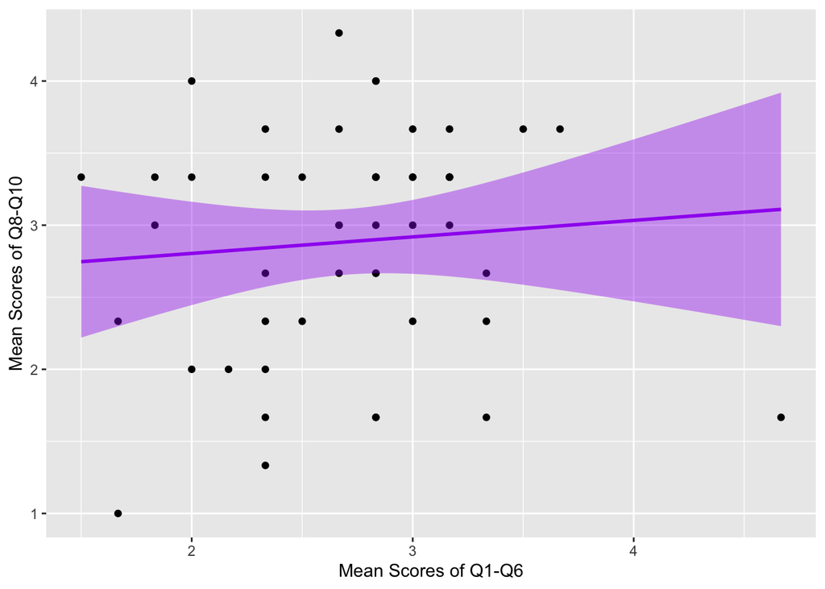

# **Analysis**

This chunk performs a correlation test using the mean scores from q1 to q6 and mean scores from q8 to q10 data. The output displays the correlation (r value) and p-value from the correlation test.

```r
cor_list <- cor.test(week8_tbl$mean_x, week8_tbl$mean_y)

cor_list$estimate
```

```
##        cor
## 0.08474575
```

```r
cor_list$p.value
```

```
## [1] 0.5626235
```

```r
rvalue_chr <- str_replace(as.character(round(cor_list$estimate, 2)), "^0", "")
```

The correlation observed is .08

# **Data Export**

This chunk exports a “skinny” version of the dataset, which only includes columns q1 to q10 and the mean_x and mean_y columns as this is what is necessary to run the code. The exported version is saved as an RDS file, as this is useful for creating a shiny app.

```r
week8_tbl %>%
  select(q1:q10, mean_x, mean_y) %>%
  saveRDS("../shiny/week8.rds")
```